# Forecasting of Tourism to Japan

MTH6139 Coursework 1

Nanjun Dai

11th March 2026

# Section 1: Introduction of this project

Background: Tourism has become an important part of many economies. In recent years, Japan has experienced a significant increase in international tourist arrivals.

Facts: Tourist arrivals usually show both long-term trends and seasonal patterns. For instance, the number of visitors often changes across months due to holidays and travel behaviour.

In this project, monthly tourist arrivals to Japan from 2003 to 2024 are analyzed. We use the Prophet model to generate the trend and seasonal patterns, and to produce a short-term forecast of future tourist arrivals.

# Section 2: Dataset and Organizaing

The dataset used in this project contains monthly international tourist arrivals to Japan from 2003 to 2024.

Monthly values were extracted from each sheet and combined into a single time series. A sequence of monthly dates was then created and matched with the extracted 264 observations to form the final dataset used for modelling.

```r
# Read the Excel Sheet of dataset
library(readxl)

file_path <- "20260218_1615-5.xlsx"

Datasheet <- excel_sheets(file_path)
targetyears <- sort(Datasheet[Datasheet >= "2003" & Datasheet <= "2024"]) # sort data, only 2003-2024 is needed

raw_list <- lapply(targetyears, function(s) {read_excel(file_path, sheet = s, skip = 4, col_names = FALSE, col_types = "text")}) # Skip some irrelevant cells
extract_monthly <- function(df) {
  x <- unlist(df[1, ], use.names = FALSE) # only consider the fist row
  cleannumbers <- x[grepl("^[0-9,]+$", x)] # as the desired value happened in every other column, filter out the numbers, only allows numbers and ","
  as.numeric(gsub(",", "", cleannumbers))[1:12] # cleaning, turn into pure numeric numbers
} # Extract desired monthly data

monthly_tourists <- unlist(lapply(raw_list, extract_monthly), use.names = FALSE) # Merge monthly data

tourism_dates <- seq(from = as.Date("2003-01-01"), to = as.Date("2024-12-01"), by = "month")

prophet_data <- data.frame( ds = tourism_dates, y = monthly_tourists) # construct a prophet
```

# Visualizing the original dataset

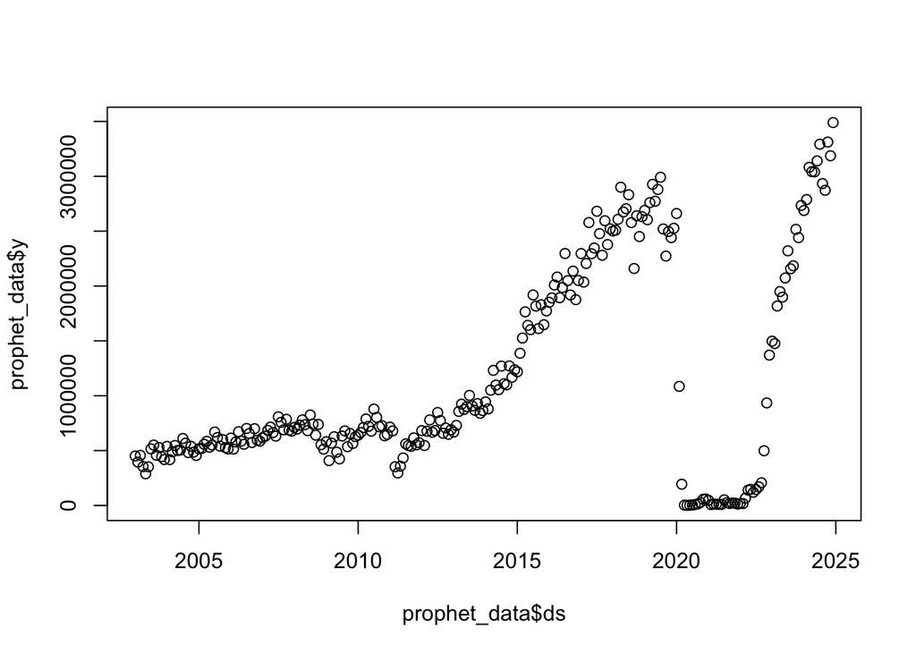

```r
plot(prophet_data$ds, prophet_data$y)
```

# Section 3: Prophet model with different settings

To model the time series, the Prophet forecasting model was used and capturing long-term trends and seasonal patterns in time series data. The model was fitted to the monthly tourist arrivals and then used to generate forecasts for the next 24 months. In this project, 3 different parameters [0.05, 0.3, 0.9] were used to show the ability to forecasting and fitting.

For the coding, we installed the prophet and ggplot, and keep the y-axis scale (0 - 6000000) all the same.

# Section 3.0: Explaination of changepoint_prior_scale

This parameter controls how easily the trend is allowed to change over time. A smaller value forces the trend to remain smooth while a larger value allows the model to adapt more strongly to changes in the data.

# Section 3.1: Model 1

```r
# Model 1: changepoint.prior.scale = 0.05
library(prophet)
```

```r
library(ggplot2)

model1 <- prophet (prophet_data, yearly.seasonality = TRUE, changepoint.prior.scale = 0.05)
```

```
## Disabling weekly seasonality. Run prophet with weekly.seasonality=TRUE to override this.
```

```
## Disabling daily seasonality. Run prophet with daily.seasonality=TRUE to override this.
```

```r
future_dates1 <- make_future_dataframe (model1, periods = 24, freq = "month")
forecast1 <- predict(model1, future_dates1)
```

# Visualizing the Forecast and Components

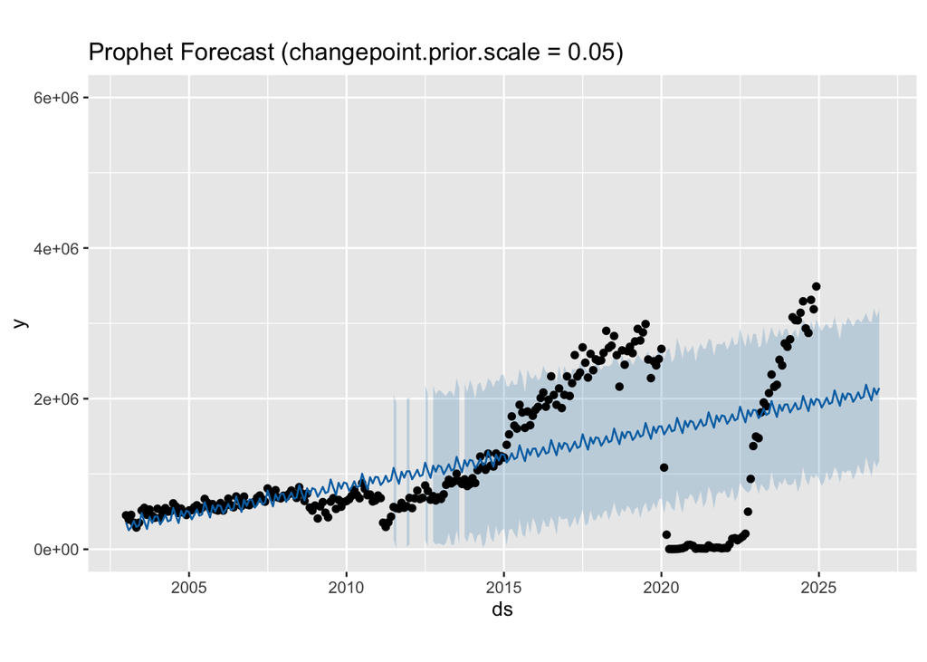

```r
plot(model1, forecast1) + ggtitle("Prophet Forecast (changepoint.prior.scale = 0.05)") + ylim(0, 6000000)
```

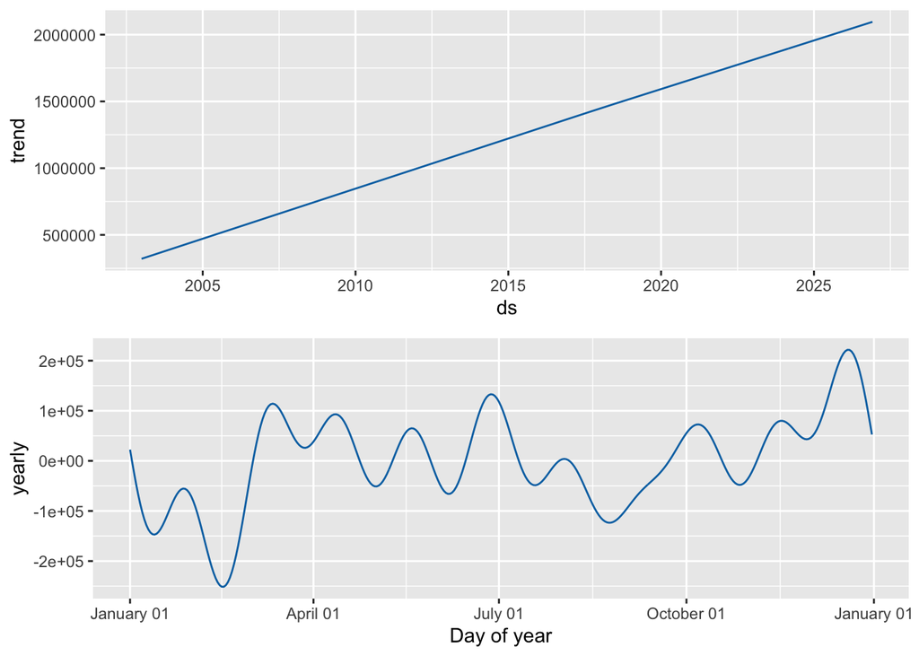

```r
prophet_plot_components(model1, forecast1)
```

# Section 3.2: Model 2

```r
# Model 2: changepoint.prior.scale = 0.3

model2 <- prophet (prophet_data, yearly.seasonality = TRUE, changepoint.prior.scale = 0.3)
```

```
## Disabling weekly seasonality. Run prophet with weekly.seasonality=TRUE to override this.
```

```
## Disabling daily seasonality. Run prophet with daily.seasonality=TRUE to override this.
```

```r
future_dates2 <- make_future_dataframe (model2, periods = 24, freq = "month")
forecast2 <- predict(model2, future_dates2)
```